# Assignment 2: Classification

Ethan Tenison

2/24/2020

# Q1: Classification

Residential solar photovoltaics (PV) – the roof-mounted panels that generate electricity – are spreading throughout Austin. Two key drivers of the individual adoption decision are Wealth in K$, and Attitude on a scale beween 1-4. Suppose you collect data on a group of Austin homeowners where $X_{1}$ = Wealth in kdollars $X_{2}$ = Attitude, and Y = whether homeowners adopt solar PV. We fit a logistic regression and produce estimated coefficients β0 = −6, β1 = 0.05, and β2 = 1.

#### (a) Write out the function.

$log$$\frac{p}{(1-p)}$ = $-6$ + $0.05$$X_{1}$ + $1$$X_{2}$

#### (b) Estimate the probability that a homeowner with Wealth of $40k and an Attitude of 3.5 adopts

solar PV.

$log$$\frac{p}{(1-p)}$ = $-6$ + $0.05$$(40)$ + $1$$(3.5)$
$log$$\frac{p}{(1-p)}$ = $-6$ + $2$ + $3.5$
$log$$\frac{p}{(1-p)}$ = $-0.5$
$\frac{p}{(1-p)}$ = $exp$$(-0.5)$
$\frac{p}{(1-p)}$ = $0.60653065971$
$p$ = $\frac{0.60653065971}{(1+0.60653065971)}$
$p$ = $37.8$%

#### (c) What Wealth value would the homeowner in part (b) need to have in order to have a 50%

chance of adopting solar PV?

$log$$\frac{0.5}{(1-0.5)}$ = $-6$ + $0.05$$X_{1}$ + $1$$(3.5)$
$log$$(1)$ = $-6$ + $0.05$$X_{1}$ + $1$$(3.5)$
$0$ = $-6$ + $0.05$$X_{1}$ + $1$$(3.5)$
$2.5$ = $0.05$$X_{1}$
$X_{1}$ = $50K$

#### (d) What if you added a qualitative variable Tesla_Owner as X3, that indicated whether the

household owns a Tesla plug-in electric car. Tesla cars are quite expensive, and those with solar PV systems benefit considerably from not paying for fuel. Write out the new function. What value might you expect for new Tesla_Owner coefficient (β3) in this new function? How might you expect β1 and β2 in the NEW function to be different from β1 and β2 in the OLD function?

$\beta_{3}$ will probably be much larger than $\beta_{1}$ and $\beta_{2}$ because Tesla owners benefit from photovoltaics. The value for $\beta_{1}$ will probably decrease slightly because wealth is correlated with owning a Tesla, and some variation previously assigned to $\beta_{1}$ will be included in $\beta_{3}$. It is unlikely that $\beta_{2}$ will change because attitude towards photovoltacics might not be associated with Tesla ownership.

#### (e) What is missing from this (admittedly simplified) analysis?

We might include an interaction variable for $X_{1}$ and $X_{3}$. You might also want to include a variable for tax rebates. Not all homeowners may qualify, and that could have a big impact on their decision. Another variable that might be important is the avg price of PV panels, which have been declining.

# Q2: Classification in data (55 points)

Water use per person in Austin is currently at an historic low, but it can still be an issue – particularly when we are experience a dry, Texas summer. Please use the Austin Water - Residential Water Consumption data (https://data.austintexas.gov/Utilities-and-City-Services/Austin-Water-Residential-WaterConsumption/sxk7-7k6z) for this question. Take note – this is a real world data set and as such may not be clean.

```r
library(dplyr)
library(janitor)
library(reshape2)
df <- read.csv("Austin_Water_-_Residential_Water_Consumption.csv")
df <- clean_names(df)
df$year <- substr(df$year_month, 1, 4)
df$year <- as.numeric(df$year)
df$month <- substr(df$year_month, 5, 6)
df$month <- as.factor(df$month)
df <- select(df, -c(year_month))
df$customer_class <- gsub(" - ", "_", df$customer_class)
df <- filter(df, postal_code != "")
df$total_gallons[is.na(df$total_gallons)] <- 0
dfwide <- dcast(data=df, postal_code+month+year~customer_class, value.var= 'total_gallons')
dfwide <- clean_names(dfwide)
df$total_gallons[is.na(df$total_gallons)] <- 0
dfwide[is.na(dfwide)] <- 0
```

#### (a) Produce some numerical and graphical summaries of the Water data. What patterns do you

see?

Total water consumption declined after water restrictions were introduced in 2018. Irrigation remained basically the same even though these numbers should have declined as well.

```r
library(ggplot2)
options(scipen=999)
print(summary(dfwide))
```

```
##   postal_code       month           year      irrigation_multi_family
##  78613  :  94   06     : 377   Min.   :2012   Min.   :       0
##  78617  :  94   07     : 377   1st Qu.:2013   1st Qu.:   28050
##  78652  :  94   08     : 377   Median :2015   Median :  565300
##  78653  :  94   09     : 377   Mean   :2015   Mean   : 1434146
##  78660  :  94   10     : 377   3rd Qu.:2017   3rd Qu.: 1923350
##  78701  :  94   01     : 376   Max.   :2019   Max.   :24298000
##  (Other):3858   (Other):2161
##  irrigation_residential  multi_family       residential
##  Min.   :      0        Min.   :       0   Min.   :        0
##  1st Qu.:      0        1st Qu.: 2370450   1st Qu.:  7162150
##  Median :  12450        Median :11954550   Median : 19374950
##  Mean   :  71293        Mean   :14931954   Mean   : 25883596
##  3rd Qu.:  45675        3rd Qu.:19102750   3rd Qu.: 39344625
##  Max.   :2704000        Max.   :92554300   Max.   :125645900
##
```

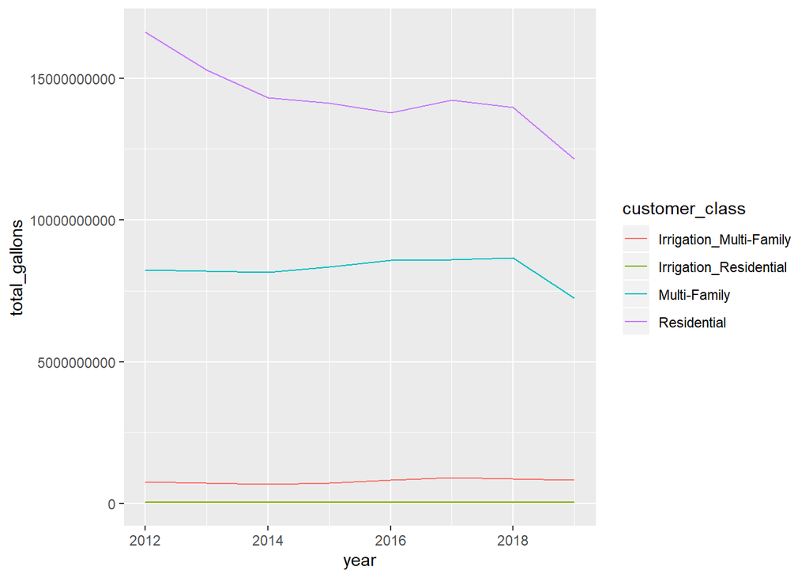

```r
total_water <- df %>% group_by(year, customer_class) %>%
                summarize(total_gallons = sum(total_gallons))

tw <- ggplot(total_water, aes(x=year, y=total_gallons, group=customer_class, color=customer_class)) +
        geom_line()
print(tw)
```

#### (b) Create a binary variable, HiResIrr, that contains a 1 if Irrigation_Residential contains a value

above its mean, and a 0 if Irrigation_Residential contains a value below its mean. Use the full data set to perform a logistic regression with HiResIrr as the response and other variables as predictors (besides the original Irrigation_Residential variable). Provide a summary of your obtained results. Do any of the predictors appear to be statistically significant? If so, which ones? Does it look like residential irrigation has decreased over the past few years?

None of the postal codes were statistically significant, so I removed them.Year, multi-family, and residential were significant and had a positive impact on the probability of HiResIrr being above the mean. For every one unit increase in year is associated with an increase in the log-odds of being above the mean by 0.055649003832. When I converted month to a factor, only the hottest months of the year are significant in the positive direction. Irrigation_multifamily was significant in the negative direction.

```r
library(caTools)
logdf <- dfwide

for (i in 1:length(logdf$irrigation_residential)){
                  if(logdf$irrigation_residential[i] > mean(logdf$irrigation_residential)){
                    logdf$HiResIrr[i] <- 1
                  }
                  else if(logdf$irrigation_residential[i] <= mean(logdf$irrigation_residential)){
                    logdf$HiResIrr[i] <- 0
                  }
}
set.seed(88)
split = sample.split(logdf$HiResIrr, SplitRatio = 0.75)
logdf <- select(logdf, -c(irrigation_residential, postal_code))
train = subset(logdf, split == TRUE)
test = subset(logdf, split == FALSE)

model <- glm(HiResIrr ~.,family=binomial(link='logit'),data=train)
summary(model)
```

```
##
## Call:
## glm(formula = HiResIrr ~ ., family = binomial(link = "logit"),
##     data = train)
##
## Deviance Residuals:
##     Min       1Q   Median       3Q      Max
## -2.1999  -0.5570  -0.3719  -0.2499   2.8841
##
## Coefficients:
##                                  Estimate        Std. Error z value
## (Intercept)             -115.962396952929   47.535119512744  -2.440
## month02                    0.283263898648    0.287384733047   0.986
## month03                    0.268087791079    0.292944928637   0.915
## month04                    0.354008960996    0.284999727342   1.242
## month05                    0.822327630847    0.274118138173   3.000
## month06                    0.738722950314    0.277826836533   2.659
## month07                    1.184888739088    0.270106101184   4.387
## month08                    1.531516976149    0.268954742030   5.694
## month09                    1.396497954700    0.271889900322   5.136
## month10                    1.235925304046    0.269595393645   4.584
## month11                    0.801228533561    0.287030089686   2.791
## month12                    0.521886160942    0.291221768812   1.792
## year                       0.055649003832    0.023577081824   2.360
## irrigation_multi_family   -0.000000426759    0.000000036306 -11.755
## multi_family               0.000000027343    0.000000003148   8.687
## residential                0.000000049457    0.000000002667  18.543
##                                     Pr(>|z|)
## (Intercept)                          0.01471 *
## month02                              0.32430
## month03                              0.36011
## month04                              0.21419
## month05                              0.00270 **
## month06                              0.00784 **
## month07                         0.0000115055 ***
## month08                         0.0000000124 ***
## month09                         0.0000002803 ***
## month10                         0.0000045536 ***
## month11                              0.00525 **
## month12                              0.07312 .
## year                                 0.01826 *
## irrigation_multi_family < 0.0000000000000002 ***
## multi_family            < 0.0000000000000002 ***
## residential             < 0.0000000000000002 ***
## ---
## Signif. codes:  0 '***' 0.001 '**' 0.01 '*' 0.05 '.' 0.1 ' ' 1
##
## (Dispersion parameter for binomial family taken to be 1)
##
##     Null deviance: 3055.8  on 3315  degrees of freedom
## Residual deviance: 2385.8  on 3300  degrees of freedom
## AIC: 2417.8
##
## Number of Fisher Scoring iterations: 5
```

#### (c) Compute the confusion matrix and overall fraction of correct predictions. Explain what the

confusion matrix is telling you about the types of mistakes made by logistic regression.

Based on this model, with a threshold of 50%, there is a high number of false positives relative to true positives.Overall it was correct $\frac{48 + 887}{1106}$ =$.84$ of the time. When I increased the threshold to 75%, the ratio of false positives to true positives improved, but the number of false negatives increased.

```r
library(caret)
p <- predict(model, test, type = "response")
print(summary(p))
```

```
##    Min. 1st Qu.  Median    Mean 3rd Qu.    Max.
## 0.01321 0.05412 0.10028 0.17570 0.22754 0.97395
```

```r
p_class <- ifelse(p > 0.5, "Predict 1", "Predict 0")
print(table(p_class, test[["HiResIrr"]]))
```

```
##
## p_class       0   1
##   Predict 0 887 144
##   Predict 1  27  48
```

```r
p_class <- ifelse(p > 0.75, "Predict 1", "Predict 0")
print(table(p_class, test[["HiResIrr"]]))
```

```
##
## p_class       0   1
##   Predict 0 908 172
##   Predict 1   6  20
```